# Lasso Regression

Philipp Wyss

2024-04-23

# 1 Load Data

Loading the hourly aggregated dataset.

```r
dat <- read.csv('../../results/df_agg_hourly.csv')
# dat <- read.csv('results/df_agg_hourly.csv')
```

Next we decide which location to use. We will use the location with the most data available.

```r
# Select the location
select_standort <- 1037

# Deciding which location to use
dat %>%
  filter(Standort == select_standort) %>%
  select(Standort, bezeichnung) %>%
  unique()
```

|  | Standort | bezeichnung |
| --- | --- | --- |
| 1 | 1037 | Hardbrücke Süd (Seite HB) |

```r
# Check the time range of the data
range(dat[dat$Standort == select_standort, ]$Datetime)
```

```
## [1] "2023-01-01 00:00" "2023-12-31 22:00"
```

# 2 Data Preperation

**Attention**: Most data preperation is taking place in `📁 ./src/data_preparation.ipynb`.

What we are doing here: 1. Cast Date and Time Variables into proper datatypes 2. Calculate the total traffic (`VELO_TOT` = `VELO_IN` + `VELO_OUT`) 3. Filter for `Standort == 1037` (Hardbrücke Süd (Seite HB)) 4. Select only variables that are of interest

```r
prep <- dat %>% mutate(
  # Cast Date & Datetime to proper Timestamps using libridate
  Date = lubridate::ymd(Date),
  Datetime = lubridate::ymd_hm(Datetime),
  Weekday = weekdays(Date),
  # Convert Time to integer
  Time = as.integer(substr(Time, 1, 2)),
  # Calculate total traffic
  VELO_TOT = VELO_IN + VELO_OUT,
  FUSS_TOT = FUSS_IN + FUSS_OUT
) %>%
  # Filter for Standort 20 (Militärbrücke / Langstrasse)
  filter(Standort == 1037) %>%
  # Select only variables that are of interest
  select(Standort,
         Date,
         Time,
         Datetime,
         Weekday,
         # Actual measurements
         VELO_TOT,
         FUSS_TOT,
         # Weather variables
         Hr...Hr.,
         RainDur..min.,
         StrGlo..W.m2.,
         T...C.,
         WD....,
         WVs..m.s.,
         WVv..m.s.,
         p..hPa.,
         # Additional lacations descriptive variables
         bezeichnung,
         richtung_in,
         richtung_out,
         korrekturfaktor) %>%
  # Transform Weekday to ordered factor starting with Monday
  mutate(Weekday = factor(Weekday,
                          levels = c("Montag", "Dienstag",
                                     "Mittwoch", "Donnerstag",
                                     "Freitag", "Samstag", "Sonntag"))) %>%
  # Create new month variable
  mutate(Month = lubridate::month(Date, label = TRUE))

# Check the first few rows
prep %>%
  select(Standort, bezeichnung, Weekday, Date, Time, VELO_TOT, FUSS_TOT) %>%
  head()
```

|  | Standort | bezeichnung | Weekday | Date | Time | VELO_TOT | FUSS_TOT |
| --- | --- | --- | --- | --- | --- | --- | --- |
| 1 | 1037 | Hardbrücke Süd (Seite HB) | Sonntag | 2023-01-01 | 0 | 29 | 0 |
| 2 | 1037 | Hardbrücke Süd (Seite HB) | Sonntag | 2023-01-01 | 1 | 66 | 0 |
| 3 | 1037 | Hardbrücke Süd (Seite HB) | Sonntag | 2023-01-01 | 2 | 91 | 0 |
| 4 | 1037 | Hardbrücke Süd (Seite HB) | Sonntag | 2023-01-01 | 3 | 58 | 0 |
| 5 | 1037 | Hardbrücke Süd (Seite HB) | Sonntag | 2023-01-01 | 4 | 40 | 0 |
| 6 | 1037 | Hardbrücke Süd (Seite HB) | Sonntag | 2023-01-01 | 5 | 19 | 0 |

# 3 EDA

Visualizing the data to get a better understanding of the data.

**Attention**: All plots and images generated here will be saved in `📁 ./results/fig_lasso_regression/`.

## 3.1 Timeseries

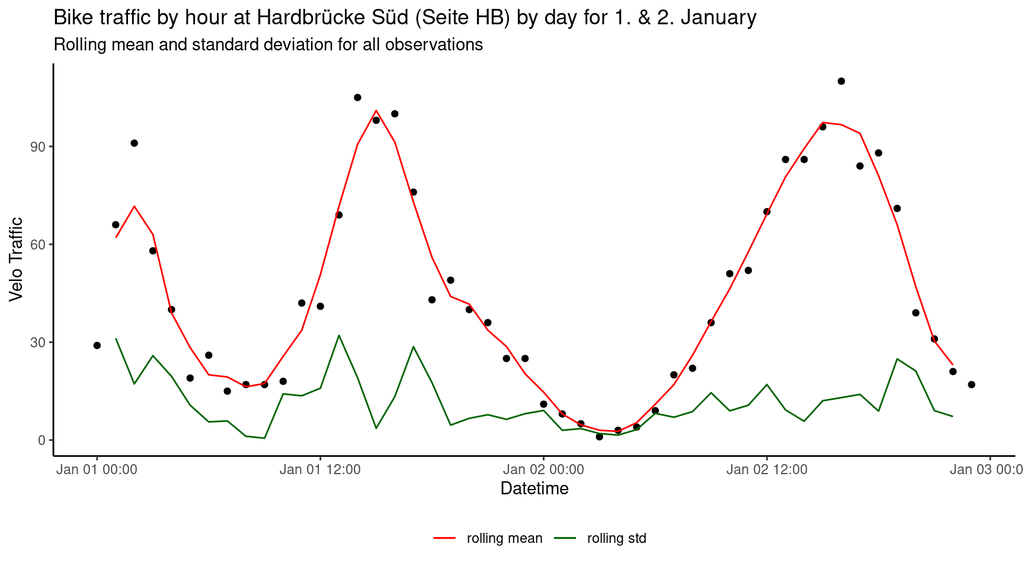

```r
prep %>%
  head(48) %>%
  # Calculate the rolling mean
  mutate(rolling_mean = zoo::rollmean(VELO_TOT, k = 3, fill = NA)) %>%
  # Calculate the rolling std
  mutate(rolling_std = zoo::rollapply(VELO_TOT, width = 3, FUN = sd, fill = NA)) %>%
  # Plot the timeseries
  ggplot(aes(x = Datetime, y = VELO_TOT)) +
  geom_point() +
  geom_line(aes(x = Datetime, y = rolling_std, colour = "rolling std")) +
  #geom_ribbon(aes(ymin = rolling_mean - rolling_std, ymax = rolling_mean + rolling_std), fill = "darkgreen", alpha = 0.2) +
  geom_line(aes(x = Datetime, y = rolling_mean, colour = "rolling mean")) +
  scale_color_manual(name = "", values = c("rolling std" = "darkgreen", "rolling mean" = "red")) +
  theme_classic() +
  theme(legend.position = "bottom") +
  ylab("Velo Traffic") +
  ggtitle(paste("Bike traffic by hour at", prep$bezeichnung[1], "by day for 1. & 2. January"), subtitle = "Rolling mean and standard deviation for all observations")
```

Next we aggregate the data on a daily basis an plot the whole year -> is there any trend?

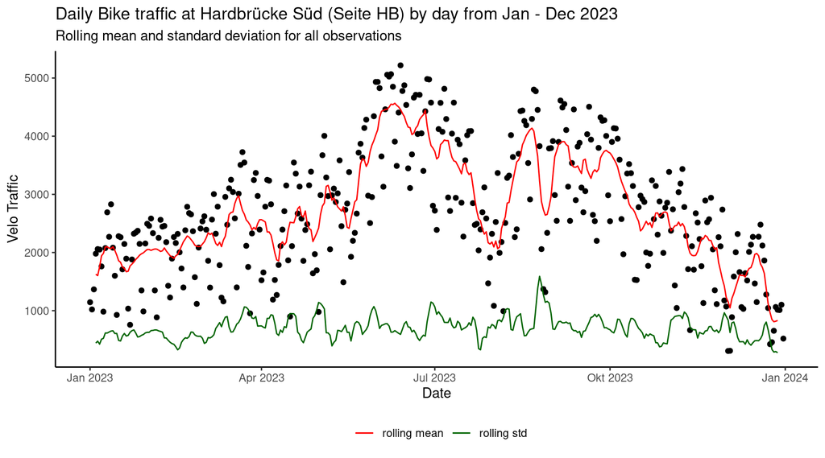

```r
# Calculate the rolling mean
prep %>%
  group_by(Date) %>%
  summarise(Traffic = sum(VELO_TOT)) %>%
  # Calculate the rolling mean
  mutate(rolling_mean = zoo::rollmean(Traffic, k = 7, fill = NA)) %>%
  # Calculate the rolling std
  mutate(rolling_std = zoo::rollapply(Traffic, width = 7, FUN = sd, fill = NA)) %>%
  # Plot the timeseries
  ggplot(aes(x = Date, y = Traffic)) +
  geom_point() +
  geom_line(aes(x = Date, y = rolling_std, colour = "rolling std")) +
  #geom_ribbon(aes(ymin = rolling_mean - rolling_std, ymax = rolling_mean + rolling_std), fill = "darkgreen", alpha = 0.2) +
  geom_line(aes(x = Date, y = rolling_mean, colour = "rolling mean")) +
  scale_color_manual(name = "", values = c("rolling std" = "darkgreen", "rolling mean" = "red")) +
  theme_classic() +
  theme(legend.position = "bottom") +
  ylab("Velo Traffic") +
  ggtitle(paste("Daily Bike traffic at", prep$bezeichnung[1], "by day from Jan - Dec 2023"), subtitle = "Rolling mean and standard deviation for all observations")
```

```r
weekday_colours <- c(
      "Montag" = "#DFE2E8",
      "Dienstag" = "#AEB7C6",
      "Mittwoch" = "#9EA8BA",
      "Donnerstag" = "#8D99AE",
      "Freitag" = "#808EA5",
      "Samstag" = "#F47382",
      "Sonntag" = "#D90429")
```

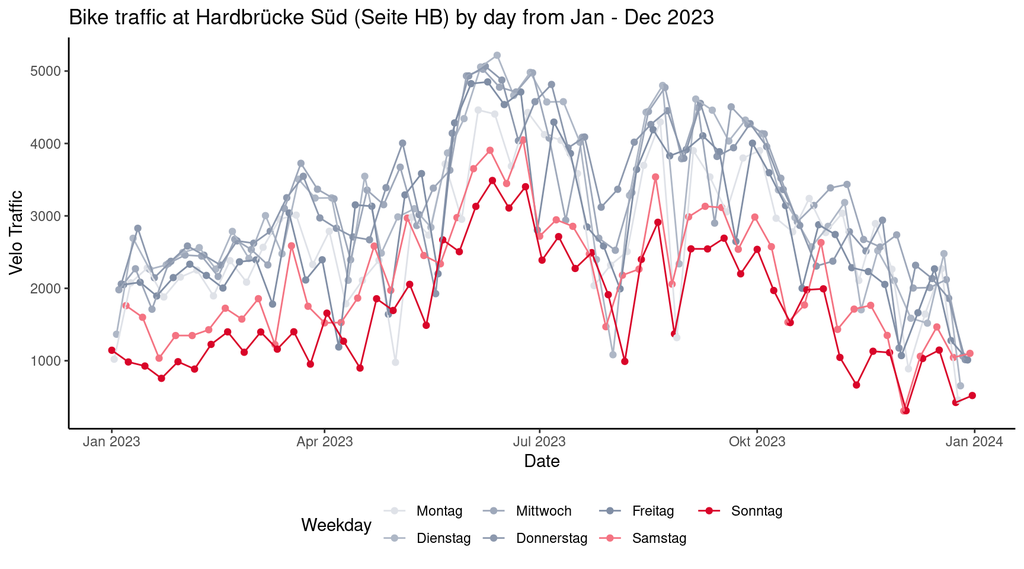

```r
prep %>%
  filter(FUSS_TOT == 0 & VELO_TOT > 0) %>%
  # Group by Date
  group_by(Date, Weekday) %>%
  # Summarize the total traffic
  summarise(Traffic = sum(VELO_TOT)) %>%
  # Plot the timeseries
  ggplot(aes(x = Date, y = Traffic, col = Weekday)) +
  geom_point() +
  geom_line() +
  theme_classic() +
  ylab("Velo Traffic") +
  ggtitle(paste("Bike traffic at", prep$bezeichnung[1], "by day from Jan - Dec 2023")) +
  theme(legend.position = "bottom") +
  # Manualy set color scale
  scale_colour_manual(
    values = weekday_colours
  )
```

## 3.2 Boxplot

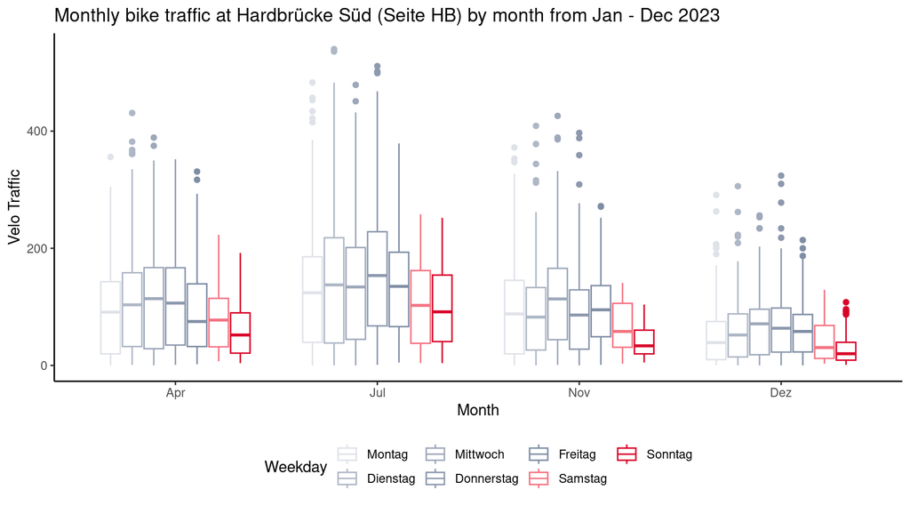

```r
prep %>%
  # Select only the variables we need
  select(Month, Weekday, VELO_TOT) %>%
  # Filter only Jan & Feb
  filter(Month %in% c("Apr", "Jul", "Nov", "Dez")) %>%
  # Plot the boxplot
  ggplot(aes(x = Month, y = VELO_TOT, col = Weekday)) +
  geom_boxplot() +
  theme_classic() +
  ylab("Velo Traffic") +
  ggtitle(paste("Monthly bike traffic at", prep$bezeichnung[1], "by month from Jan - Dec 2023")) +
    theme(legend.position = "bottom") +
    # Manualy set color scale
  scale_colour_manual(
    values = weekday_colours
  )
```

## 3.3 Correlation Matrix

```r
# Calculate the correlation matrix
cor_matrix <- prep %>%
  select(VELO_TOT, Hr...Hr., RainDur..min., StrGlo..W.m2., T...C., WD...., WVs..m.s., WVv..m.s., p..hPa.) %>%
  cor()

print(round(cor_matrix[1,],4))
```

```
##      VELO_TOT      Hr...Hr. RainDur..min. StrGlo..W.m2.        T...C.
##        1.0000       -0.4540       -0.1464        0.3061        0.4047
##        WD....     WVs..m.s.     WVv..m.s.       p..hPa.
##       -0.1089        0.0492        0.0072        0.0000
```

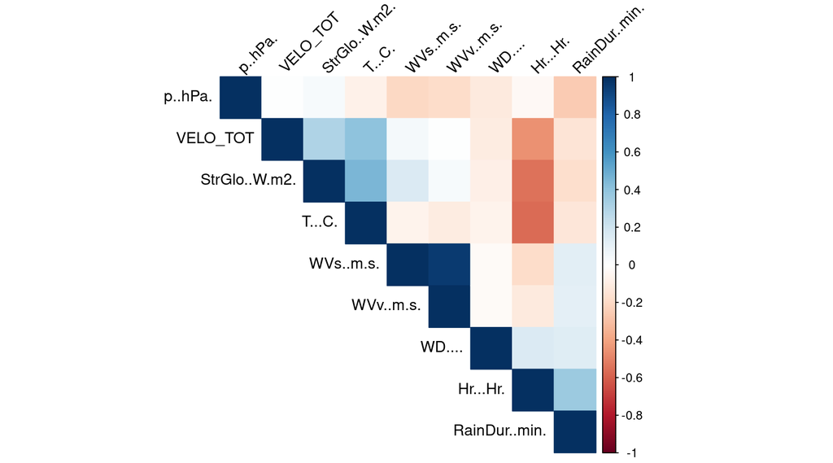

```r
# Plot the correlation matrix
corrplot::corrplot(cor_matrix, method = "color", type = "upper", order = "hclust", tl.col = "black", tl.srt = 45)
```

## 3.4 Plot RainDur

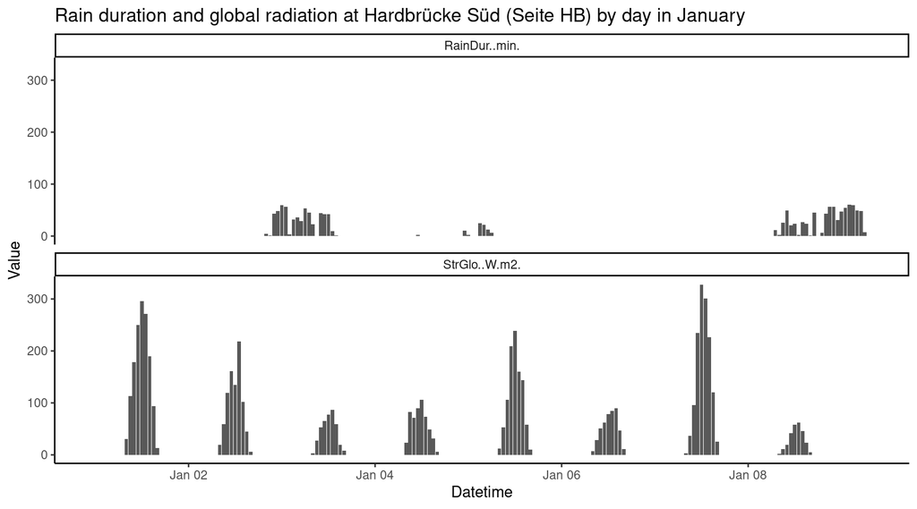

```r
# Plot RainDur and StrGlo as a function of Datetime
# First transfrom the data to long format
# Then plot the values as bars and add facet_wrap by the variable
prep %>%
  head(200) %>%
  pivot_longer(cols = c(RainDur..min., StrGlo..W.m2.),
              names_to = "Variable",
              values_to = "Value") %>%
  ggplot(aes(x = Datetime, y = Value)) +
  geom_bar(stat = "identity") +
  facet_wrap(vars(Variable), ncol = 1) +
  theme_classic() +
  ylab("Value") +
  ggtitle(paste("Rain duration and global radiation at", prep$bezeichnung[1], "by day in January")) +
  theme(legend.position = "bottom")
```

# 4 Time Series Analysis

The log-transformed timeseries looks lot more **stationary**.

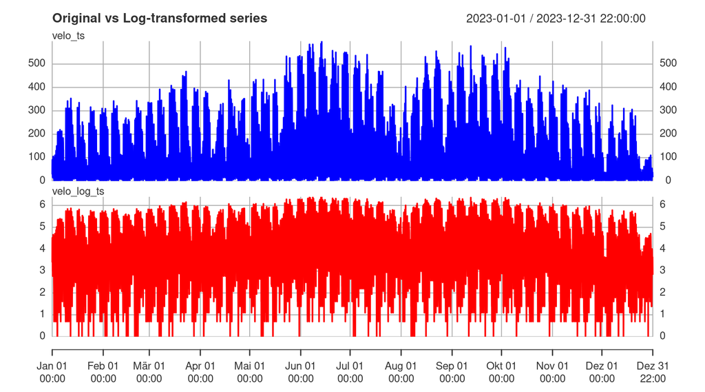

```r
# Create a time series object using xts
velo_ts <- xts::xts(x = prep$VELO_TOT,
               order.by = prep$Datetime,
               frequency = 8758)

# Create a log transformed time-series
velo_log_ts <- log(velo_ts + 1)

# Merge the series
velo_ts_merge <-  merge.xts(velo_ts, velo_log_ts)

# Plot the time series
plot.xts(velo_ts_merge, col = c("blue", "red"),
         multi.panel = TRUE, yaxis.same = FALSE,
         main = "Original vs Log-transformed series")
```

To remove the seasonal pattern, we might want to use a seasonally-adjusted time series. Otherwise, we could also create a dummy variable for the seasonal period (that is, a variable that characterises the weekends).

We will be using the manualy created variable `weekday` (ordered factor) for compensating for the weekends.

### 4.0.1 ACF

The ACF statistic measures the correlation between xt and xt+k where k is the number of lead periods into the future. It measures the correlation between any two points based on a given interval. It is not strictly equivalent to the Pearson product moment correlation. In R, ACF is calculated and visualized with the function “acf”.

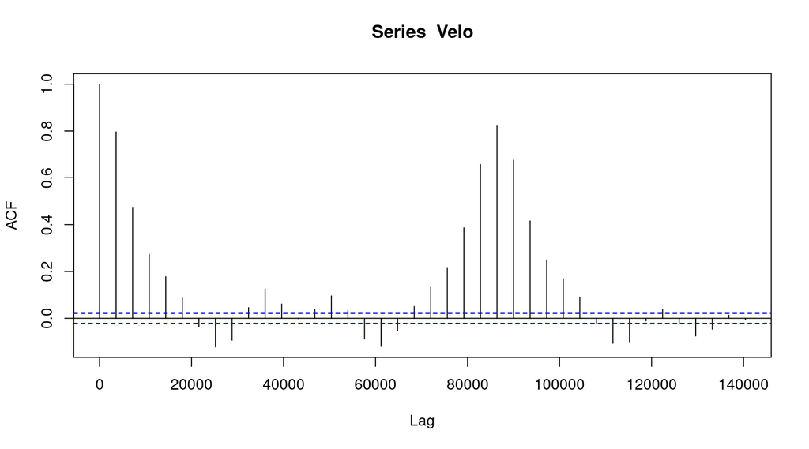

```r
acf(Velo)
```

## 4.1 Linear Model

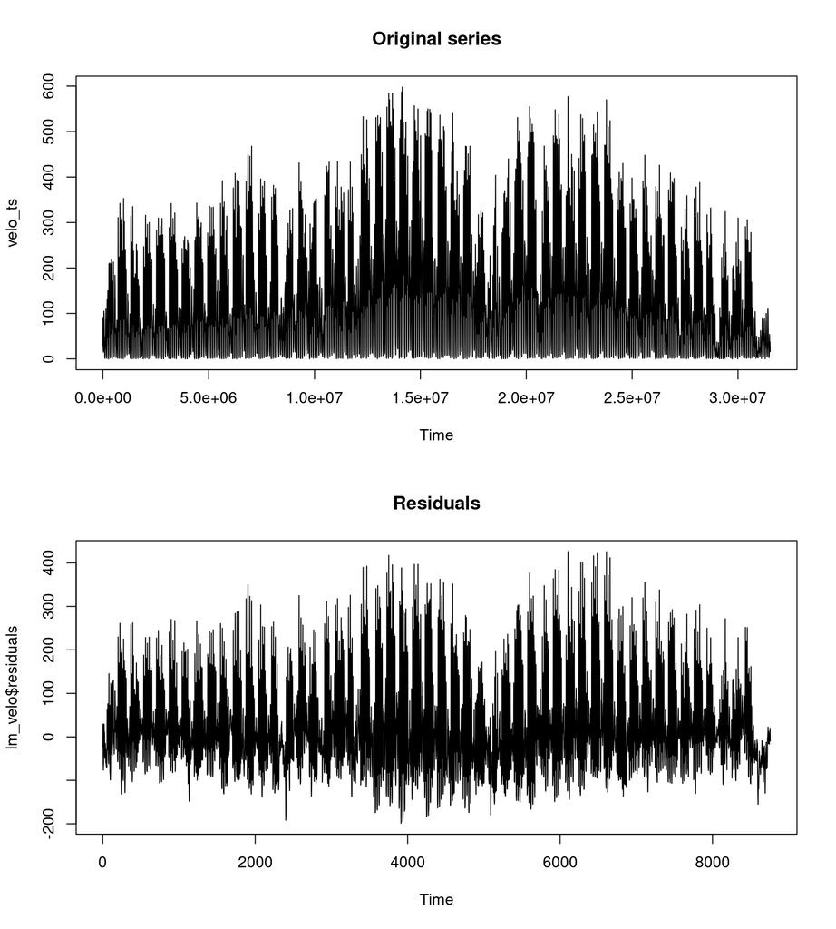

```r
# Build multivariate linear model
lm_velo <- prep %>% lm(VELO_TOT ~ Weekday + Datetime + Hr...Hr. + RainDur..min. + StrGlo..W.m2. + T...C., data = .)

par(mfrow = c(2,1))
plot.ts(velo_ts, main = "Original series")
plot.ts(lm_velo$residuals, main = "Residuals")
```